# Product Sales Project

Rodrigo Conrado Cortés Montes de Oca

2025-10-20

# Introduction

A new line of office stationery were launched 6 weeks ago. In focus to optimize the sales and revenues for our company three sales strategies were implemented: Email, Call and Email + Call. In this report we analyze the effectiviness of these strategies and insights which may be the best strategy in the future.

The following report is divided in:

- Data Validation and cleaning process of the dataset.
- Exploratory Analysis of the different variables, their differences and their relationships.
- Definition of a metric for our buissnes to monitor and assess the efectiviness in the future.
- Final summary and recomendations

# Data Validation

The data recieved consist in 8 variables with 15,000 observation or registers. The variables are the following:

- **week**: Week sale was made, counted as weeks since product launch, stored as a integer, but acts as a category nominal level. From 1 to 6. No empty values were identified in this column. No modifications were necessary
- **sales_method**: This column is stored as a caracter, so an adjustment was employed to store as a factor with three nominal categories: “Email”, “Call”, “Email + Call”. In the validation process were identified some misspeled words such as “em + call” and “email”, so an unification were employed to fit this categories in their correct factor. No empty values were identified in this column. A total of 3 groups and 15,000 regisers in total were confirmed.
- **customer_id**: This is unique for each customer. No duplicates or missing values were identified. No changes were necessary.
- **nb_sold**: Number of units sold. The number of products needs to be a integer. No double (continuous) numbers or empty values were identified. No changes were necessary in this column.
- **revenue**: Revenue from the sales, rounded to 2 decimal places. 1074 empty values were identified as NA, and replaced with the mean of the non-na values. No other changes on this column were necessary.
- **year_as_customer**: Number of years that a customer has been buying from our stores. As the maximum value coherent in this case is 41 (accordingly with the foundation year 1984), two abnormal outliers were identified and replaced with the maximum value possible 41. No missing values were identified and no other changes were necessary.
- **nb_site_visits**: The number of visits in our website in the last 6 months that a customer has made. No missing values were identified and no changes where necessary.
- **state**: States of the United States as a full name. This column is stored as a caracter, so an adjustment was employed to store as a factor with 50 different countries identified.

```
##       week             sales_method  customer_id           nb_sold
##  Min.   :1.000   Email       :7466   Length:15000       Min.   : 7.00
##  1st Qu.:2.000   Call        :4962   Class :character   1st Qu.: 9.00
##  Median :3.000   Email + Call:2572   Mode  :character   Median :10.00
##  Mean   :3.098                                          Mean   :10.08
##  3rd Qu.:5.000                                          3rd Qu.:11.00
##  Max.   :6.000                                          Max.   :16.00
##
##     revenue       years_as_customer nb_site_visits           state
##  Min.   : 32.54   Min.   : 0.000    Min.   :12.00   California  :1872
##  1st Qu.: 53.04   1st Qu.: 1.000    1st Qu.:23.00   Texas       :1187
##  Median : 91.86   Median : 3.000    Median :25.00   New York    : 965
##  Mean   : 93.93   Mean   : 4.964    Mean   :24.99   Florida     : 904
##  3rd Qu.:106.07   3rd Qu.: 7.000    3rd Qu.:27.00   Illinois    : 617
##  Max.   :238.32   Max.   :41.000    Max.   :41.00   Pennsylvania: 598
##                                                     (Other)     :8857
```

```
##
##        Email         Call Email + Call
##         7466         4962         2572
```

```
## [1] "The total of customers is 15000"
```

```
## [1] "The total of groups are 3"
```

```
## [1] "The total of individual customers is 15000"
```

```
## [1] "The total of duplicates is 0"
```

```
## [1] "The total of states is 50"
```

# 1. Number of Customers for each Sales Method

A total of 15,000 customers were included in the analysis, these customers were assigned into one of the three sales strategies. The method with most customers was “Email” with 7,466 customers, followed by “Call” with 4962 customers and lastly “Email + Call” with 2572 customers.

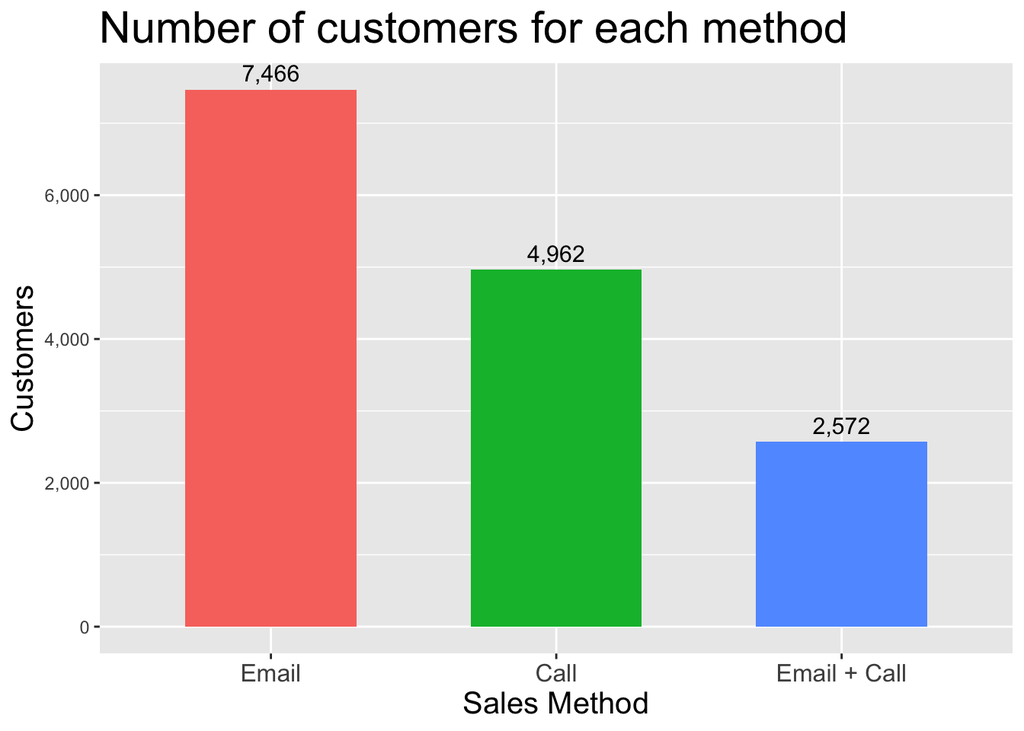

# 2. Spread of Revenue

## 2.1. Overal Spread of Revenue

[figure not shown]

## 2.2 Spread of revenue for each sales method

To evaluate the spread of revenue for each method, a boxplot was created. To evaluate if the overall revenue grouped by each strategy a statistical test was used. To confirm the election for the statistical test a QQ plot and Levene test was employed, defining the election for Kruskal Wallis test, denoting that there is statistical difference between the customer revenue by each group and between all of them.

This means, the customers in the Email + Call group tended to generated more revenue, followed by the Email group, and lastly the customers in the Call group.

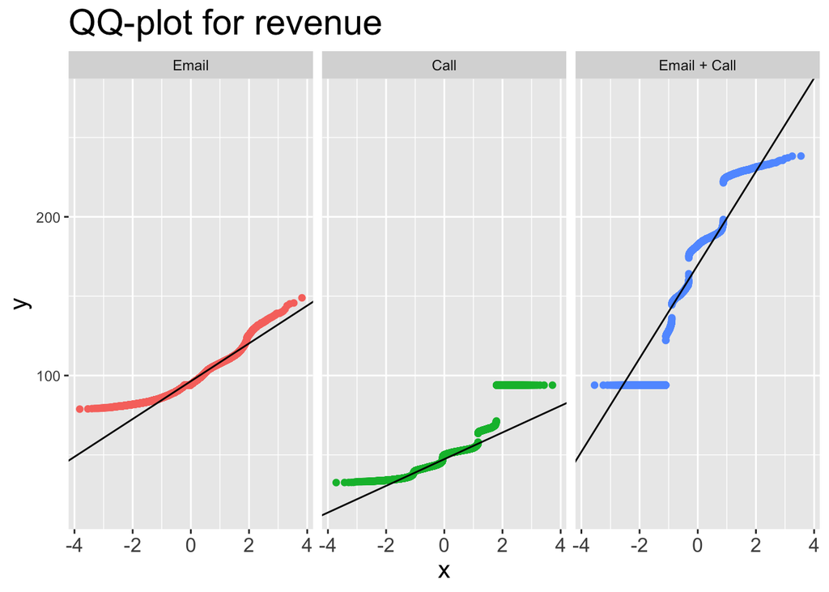

|  | Df | F value | Pr(>F) |
| --- | --- | --- | --- |
| group | 2 | 2826.116 | 0 |
|  | 14997 | NA | NA |

```
##
##  Kruskal-Wallis rank sum test
##
## data:  revenue by sales_method
## Kruskal-Wallis chi-squared = 11375, df = 2, p-value < 2.2e-16
```

```
##
##  Pairwise comparisons using Wilcoxon rank sum test with continuity correction
##
## data:  data_val$revenue and data_val$sales_method
##
##              Email  Call
## Call         <2e-16 -
## Email + Call <2e-16 <2e-16
##
## P value adjustment method: bonferroni
```

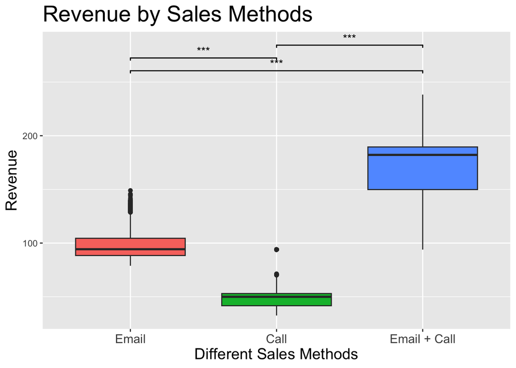